# Loading cleaning CTD data from RREA

This code was written by II for the manuscript: https://doi.org/10.1093/icesjms/fsae129 This code is preceded by “Analysis 1.Rmd” and followed by “Ocean regrid.Rmd”

# Objective of code

This project was created to load CTD data from the RREAS survey and to select those data corresponding to our acoustic tracks. These data will then be used to determine which environmental drivers might be responsible for affecting the acoustic Center of Mass (M) depth.

- load CTD data (metadata (ctd_header) + vertical profile data (ctd_cast))- and clean and link these tables
- select for CTD stations that recorded data to 500m
- select for physical variables of interest at specific depths of interest (150m, CM depth 314 m, 500m)

# Load libraries:

# Plot acoustic tracks

We can create a simple plot of the location of our acoustic backscatter data from the echo_integration data Lat and Lon data which represents the center point of each 100m horizontal water column (from 175m-675m) of data. Note that this is prior to re-gridding into 25 by 25km grid cells

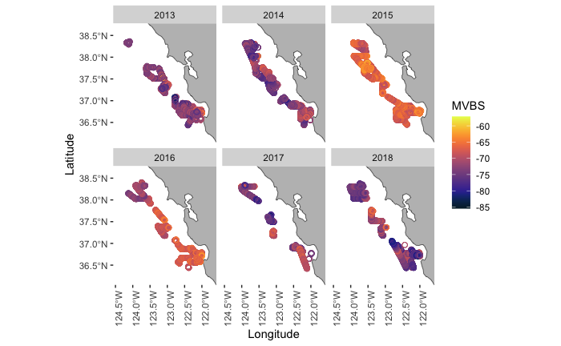

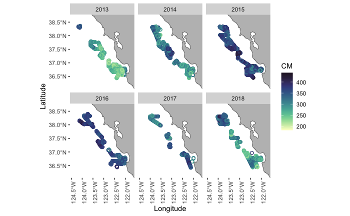

# Load CTD data from RREA survey into R

These data are currently stored in a folder labeled ctd_data. To run the following code,download the CTD files from Dryad and store in a working directory under the same name. (dbo_CTD_HEADER.txt, dbo_CTD_CAST.txt, stations.csv)

```r
# Read ctd header info (ctd metadata)
ctd_header <- read.csv(file="./ctd_data/dbo_CTD_HEADER.txt", header = TRUE, sep=",", stringsAsFactors = FALSE)
#add stringsAsFactors=FALSE to solve later error in utf-8

# load CTD cast info (vertical oceanographic data)
ctd_cast <- read.csv(file="./ctd_data/dbo_CTD_CAST.txt", header = TRUE, sep=",", stringsAsFactors = FALSE)
```

# Clean up imported CTD data- select for survey years of interest (2013:2018)

-convert lat lon -col for year *Note CTD_LAT and CTD_LON are the position info for the actual locations of the CTD (not the station position that was the likely target location)

```r
# clean up CTD data
ctd_header <- ctd_header %>%
            mutate(date_parsed= mdy_hms(CTD_DATE)) %>% # create a new variable (column) parsing the date from factor to POSIX ct and t
            mutate(Year= year(date_parsed)) %>% # create a new column "year" which extracts the year info from our parsed date column
            mutate(day_ctd= as_date(date_parsed))%>% #create a new col with day
            rename(y = CTD_LAT, x = CTD_LONG) %>% # rename our latitude (y) and longitude (x) columns
            mutate(lat.d  = as.numeric(str_sub(y, start=1, end= 2)), #create a new column of first 2 terms dd from latitude
            lat.m  = as.numeric(str_sub(y, start=3, end=6)), # extract minutes terms (mm.mm) from 3-6 position in lat col
            LATITUDE    = lat.d + lat.m/60, # divide mm.mm by 60 and add to dd terms
            long.d = as.numeric(str_sub(x, start=1, end= 3)), #first 3 terms ddd
            long.m = as.numeric(str_sub(x, start=4, end=7)), #extract mm.mmm terms in position 4-7
            LONGITUDE = -(long.d + long.m/60)) %>% # create new col for longitude, note - for longitude values
            dplyr::select(-c(lat.d, long.d, lat.m, long.m, x, y)) |>  #remove intermediary columns
            rename(year=Year)

#create vector of years of our study
survey_yrs <- 2013:2018

# Select for our years of interest: 2013-2018
 ctd_header <- ctd_header %>%
                filter(year %in% survey_yrs)

#the code above converts CTD_LAT to LATITUDE and CTD_LONG to LONGITUDE variables in decimal degrees- this is the specific position of a given CTD, not the station position. Note there is a value for each record.

 # select for our years of interest (2013-2018) for the vertical profile info:Because we haven't merged these data to date cols, can only select by CRUISE ID. Note this is just in an effort to reduce the size of the df (a lot of data with all years + all casts)


 cruise_yrs <- c(1305, 1405, 1505, 1603, 1703, 1802)

ctd_cast<-  ctd_cast %>%
   filter(CRUISE %in% cruise_yrs)

# this selects for the vertical profile data for the years 2013--2018
```

# Plot acoustic tracks + CTD locations (all CTDs, regardless of depth)

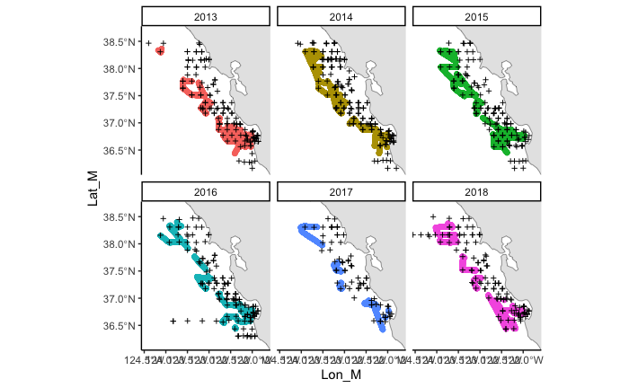

```r
ggplot()+
  geom_sf(data=states)+
  geom_point(data=echo_integration, aes(x=Lon_M, y=Lat_M, color=year), show.legend = F)+ #plot acoustic tracks
  geom_point(data=ctd_header, aes(x= LONGITUDE, y=LATITUDE), color="black", shape=3,  size=1, show.legend = F)+
  coord_sf(crs=st_crs(states), xlim = c(min(echo_integration$Lon_M-0.25), max(echo_integration$Lon_M+0.25)), ylim = c(min(echo_integration$Lat_M-0.25), max(echo_integration$Lat_M+0.25)))+
  facet_wrap(~year)+
  theme_classic()
```

# Join vertical CTD data (ctd_cast) to our metadata (ctd_header for 2013:2018)

The following adds all CTD oceanographic variables to our header data for ALL (regardelss of depth) 2013:2018 sites

```r
#left join ctd_cast (CTD vertical data) to CTD station metadata (ctd_header) - in this case all CTD casts (regardless of depth, from 2013-2018)
ctd_data <- left_join(x=ctd_header, y=ctd_cast, by=c("CRUISE","CTD_INDEX"))

# add ctd_cast to ctd_header df by the cols CRUISE and CTD_INDEX (unique casts)

# each obs (row) represents a CTD data point (for multiple variables- columns) at a particular location
rm(cruise_yrs, survey_yrs)
```

# Determine the deepest depth a given CTD cast actually recorded vertical data to!

Select casts that went at least 500m deep

```r
# Create a df of those CTD casts (unique CRUISE and CTD_INDEX) with a max depth (last row per CTD_INDEX) of at last 150m

ctd_deep <- ctd_data %>%
  group_by(CRUISE, CTD_INDEX) %>% #unique code for each year + CTD cast
  slice(n())%>% # select the last row for each unique CTD (CTD_INDEX) (and year)
  dplyr::select(CRUISE, CTD_INDEX, CTD_BOTTOM_DEPTH, CTD_DEPTH)%>%
  filter(CTD_DEPTH>= 500)

# keep only CRUISE and CTD_INDEX (going to join by these values and don't want redundant depth columns -- need to add ALL records per cast)
ctd_deep <- dplyr::select(ctd_deep, c(CRUISE, CTD_INDEX))

# select for CRUISE and CTD_INDEX and join to that df
ctd_deep_data <- left_join(x= ctd_deep, y=ctd_data, by=c("CRUISE", "CTD_INDEX"))


# remove intervening dfs
rm(ctd_deep, ctd_data)

# remove initial tables as ctd_deep_data now has all info from 2013:2018 for those CTD casts where the recorded depth was at least 150m
rm(ctd_cast, ctd_header)
```

# Updated map of acoustic track and CTD casts – create unique location df

```r
# create df of unique locations - since already have code for selecting the last entry per cast, going to do the same here
# this has the added benefit of having the max depth an individual CTD sampled
ctd_deep_loc <- ctd_deep_data %>%
                group_by(CRUISE, CTD_INDEX) %>% #unique code for each year + CTD cast
                slice(n())%>% # select the last row for each unique CTD (CTD_INDEX) (and year)
                dplyr::select(CRUISE, CTD_INDEX, CTD_BOTTOM_DEPTH, CTD_DEPTH, LATITUDE, LONGITUDE, year)
```

# Plot CTD locations (casts that recorded data to at least 500m) over acoustic tracks

Plotted the ctd index value so we can remove those outside study region

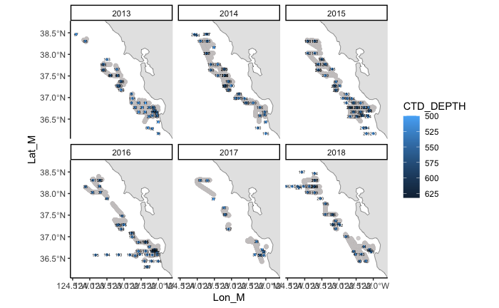

```r
# Plot these locations with our acoustic track
ggplot()+
  geom_sf(data=states)+
  geom_point(data=echo_integration, aes(x=Lon_M, y=Lat_M), color="snow3", alpha=0.5, show.legend = F)+ #plot acoustic tracks
  scale_color_viridis_d()+
  geom_point(data=ctd_deep_loc, aes(x= LONGITUDE, y=LATITUDE, fill=CTD_DEPTH), color="transparent", shape=21,  size=1, show.legend = T)+
  geom_text(data=ctd_deep_loc, aes(x=LONGITUDE, y=LATITUDE, label=CTD_INDEX), size=1.5, hjust=0.5, vjust=0.5)+
  scale_fill_continuous(trans = 'reverse')+ #reverse color scale
  coord_sf(crs=st_crs(states), xlim = c(min(echo_integration$Lon_M-0.25), max(echo_integration$Lon_M+0.25)), ylim = c(min(echo_integration$Lat_M-0.25), max(echo_integration$Lat_M+0.25)))+
  facet_wrap(~year)+
  theme_classic()
```